# Notes on response to comment from Kaifu

Ben Marwick

06 Sep 2017

## 0.1 OSL ages for lowest artefact band are consistent across the site

Kaifu and Shitaoka write:

“First, the OSL ages for the lowest dense artifact band (called as the ‘zone of initial human occupation’) are different as much as 10,000 years between the two main sections. The ages were ~53,000–55,000 years ago at square B4 (SW–A series), whereas ~57,000–65,000 years ago at a location one meter apart from there (SW–B/C series at square B5). The lower limit of this artifact band at square B4 has been lowered in Extended Data Figure 8c (the lower stippled line), but this must be an error because such a lower limit cannot be supported from the artifact distribution and the lithic artifact refitting analysis illustrated in Extended Data Figures 1, 2 and 6. The observed internal inconsistency indicates that either or both of the OSL ages have considerable errors.”

So let’s see what is the age of phase 2 in square B4 compared to B5.

[figure not shown]

Here is EDF 8C, showind OSL samples in the section of B4, the white stipple indicate the lowest dense layer of stone artefacts, the upper boundary of this layer passing between OSL samples SW9A and SW10A:

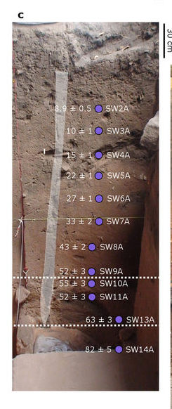

Here is EDF 1, the stipple lines here do *not* indicate artefact deposits, but instead indicate stratigraphic boundaries. The line passes between SW10A and SW11A, indicating that the stratigraphic boundary is below the top of the artefact layer. The artefact layer and stratigraphic boundaries do not align exactly. The 1989 pit is a stratigraphic feature, notated here with a stipple line, because of its distinctive texture and colour, in addition to having a high density of artefacts. This misinterpretation of the stipple lines in EDF8c and EDF 1 is the source of the first objection by K & S.

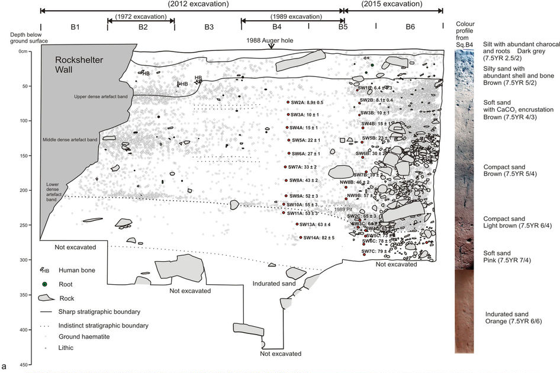

Here is EDF 2, below, showing the locations of the phases of artefacts. Phases 2 is the lowest dense layer, identified on EDF 1 as the ‘Lower dense artefact band’, and in EDF 8c by the stipple lines. Recalling that the stipple line in EDF 1 is a stratigraphic indicator rather than an indicator of an artefact layer, we see no inconsistency between EDF 2 and the other figures.

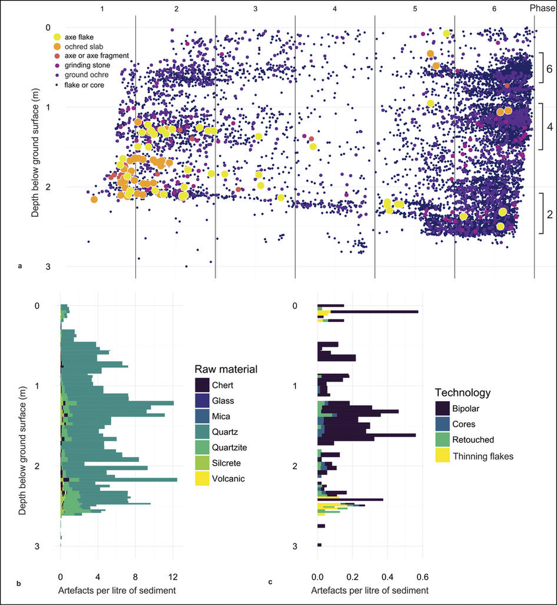

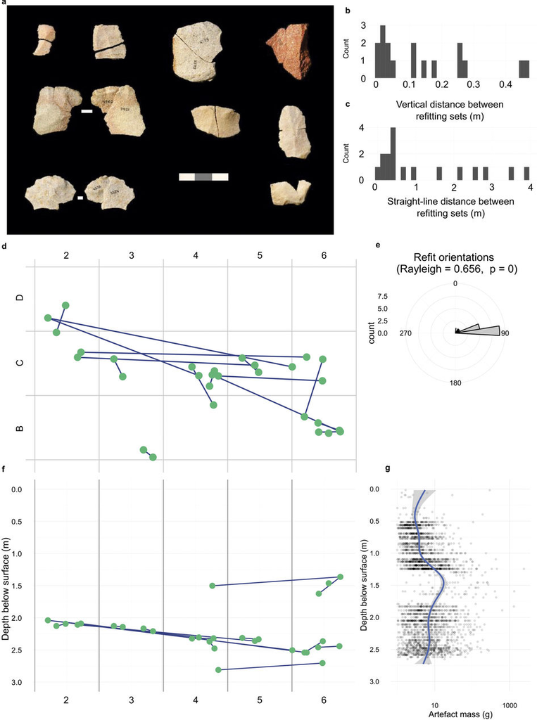

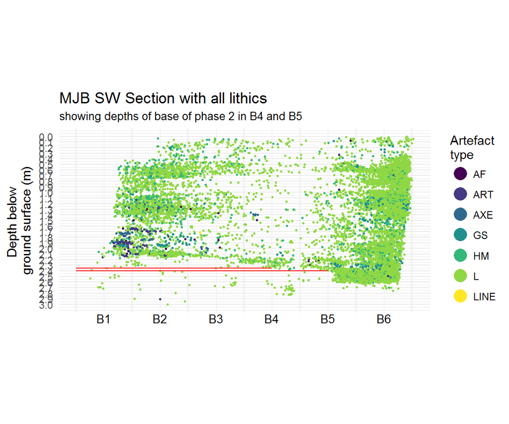

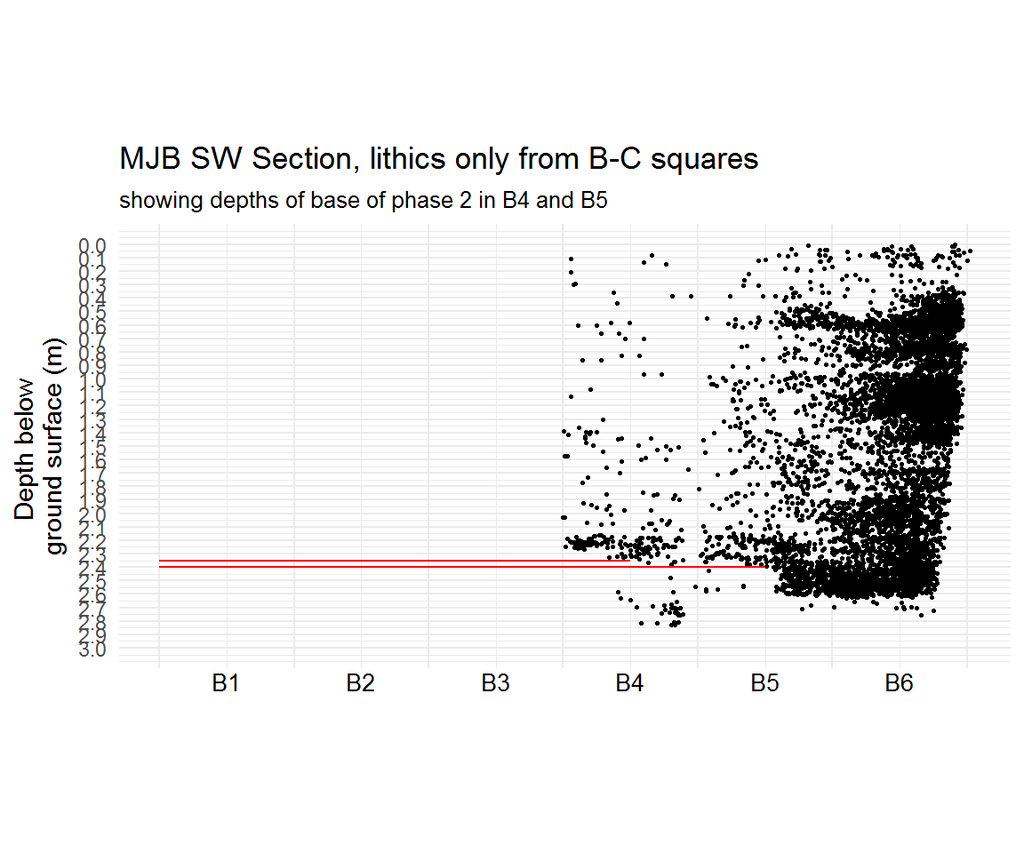

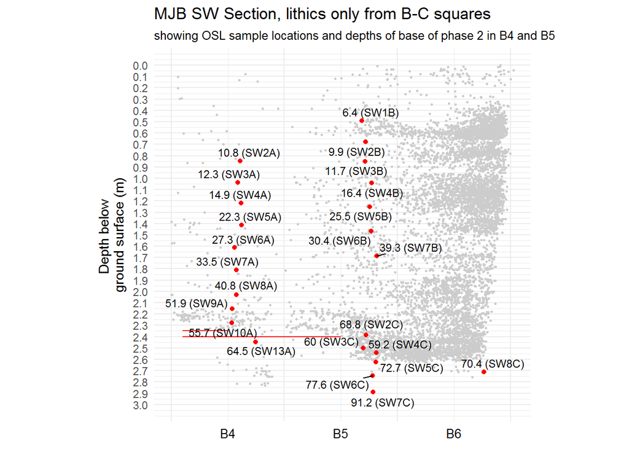

Let’s look at the artefact discard patterns in these squares:

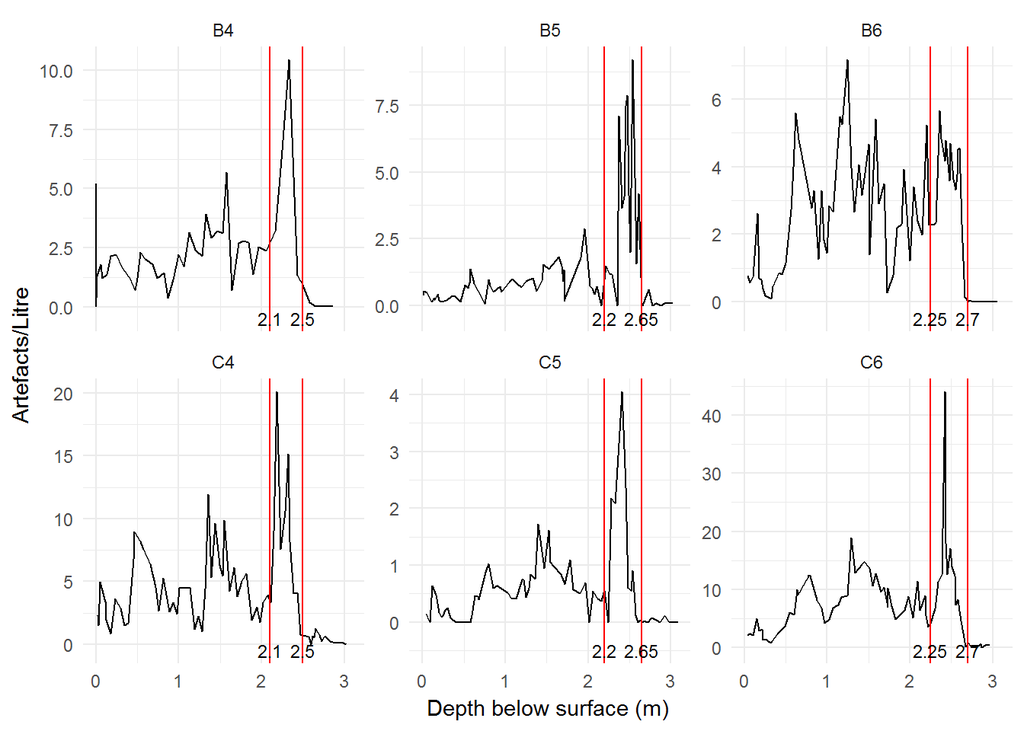

## 0.2 OSL and C14 ages are in agreement with each other

Kaifu and Shitaoka write:

“Second, contrary to the authors’ statement, the reported radiocarbon and OSL chronologies are not in agreement with each other. Among the seven radiocarbon ages measured below the –110 cm level (> 20,000 years ago in the OSL time scale), six of them collectively shows its own time trajectory which is younger than the OSL time scale in Extended Data Figure 8g. Clarkson and colleagues suggested ~30–50 cm downward relocation for the two dated charcoals either by artificial or natural processes (Supplementary Information, p.18 in ref. 1). Even if we accept this possibility, the claimed consistency is unsound in the lower stratigraphic section because it is supported by single isolated charcoal (OZT592). Such a piece could be intruded from nearby older deposit in a sandy area like Madjedbebe.”

“The data from the squares E and D series show more obvious inconsistency between the two dating methods, although this point was not mentioned by Clarkson and colleagues. Stratigraphic correlations could not be established between the opposite ends of the excavated grids, that is, between the area around square B4 and the area around square E2 (ref. 1). Because of this, the OSL ages plotted in Extended Data Figure 8g were restricted to the former (square B4, B5, and C4), although this chart includes radiocarbon ages from both areas (C3, C4, C5, E3, and E4) except for the data from square D2 (Wk43606). In order to look at tendency in each area, in Table 1, we compiled two regional data sets from Supplementary Tables 2, 5, and 6 (ref. 1), focusing on chronologies between the –90 and –200 cm levels from where the radiocarbon data are available. In the area around E2, two radiocarbon ages from the hearths at about –100 cm level (Wk43610 and Wk43606) are younger than the OSL age 10 cm above (NE3) by ~3,000–7,000 years. Overall, the radiocarbon data suggests a younger chronology than the OSL results, or more appropriately, the number of reported radiocarbon ages is too small to settle this question.”

So, let’s have a look at the correlation between the C14 and OSL ages at the site.

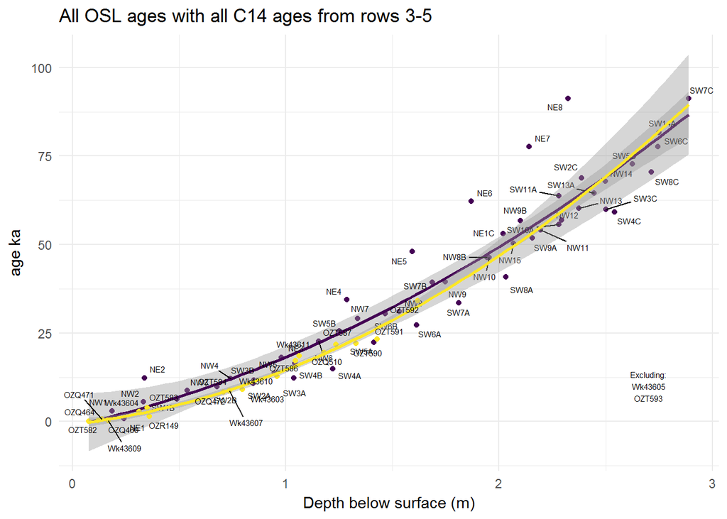

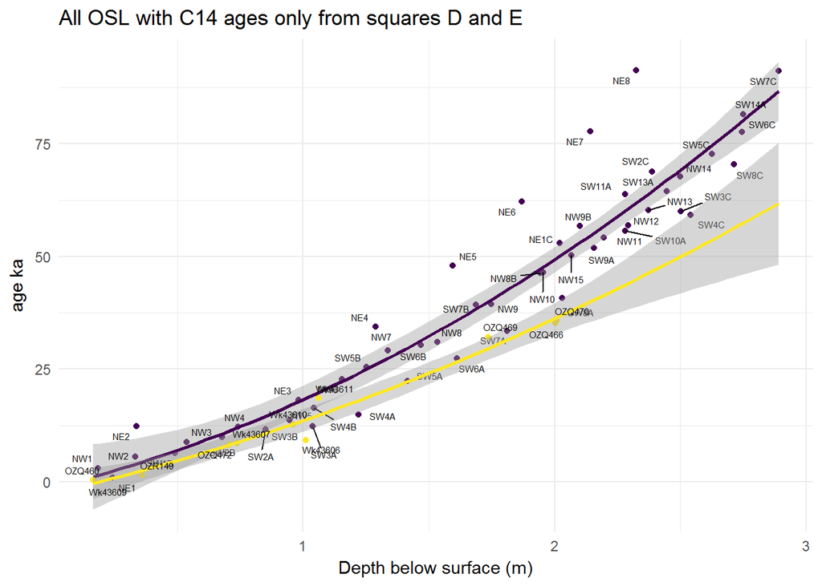

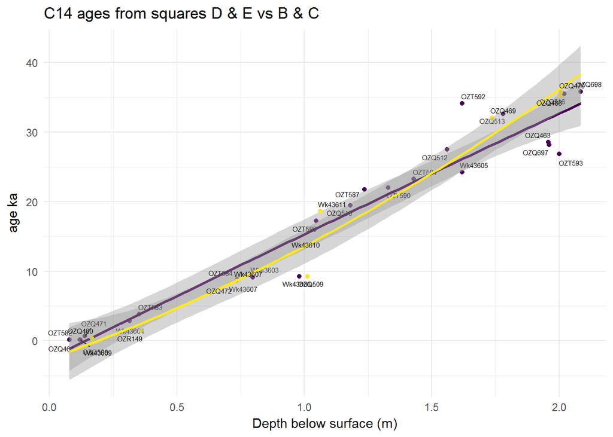

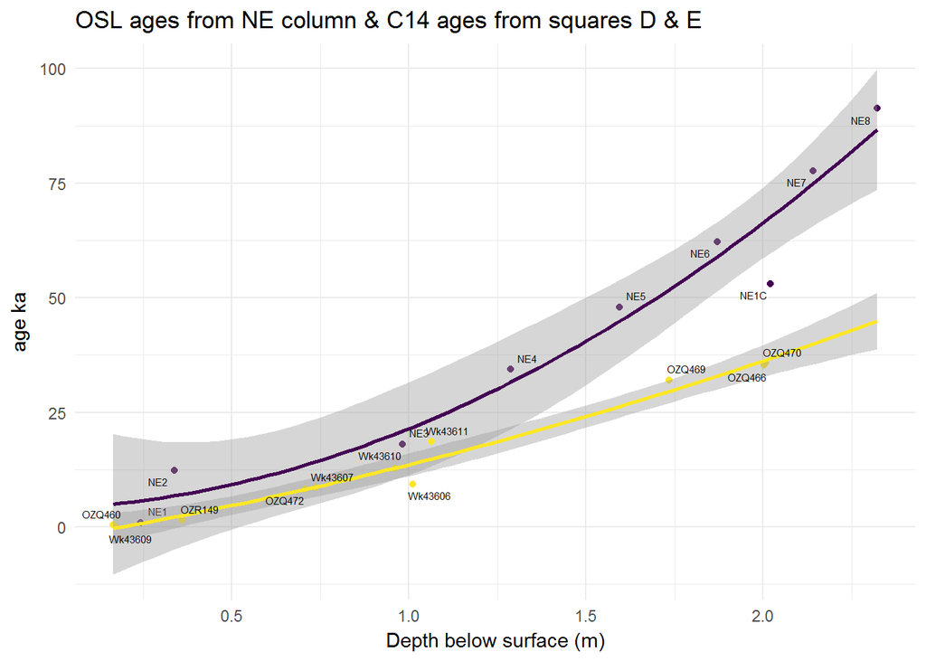

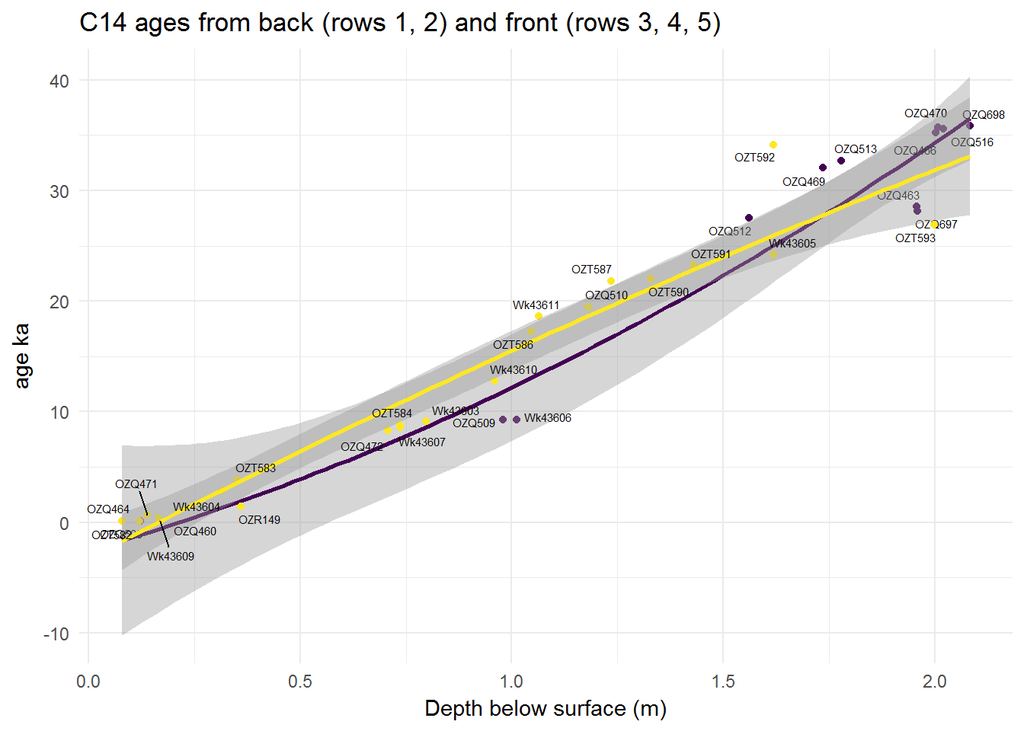

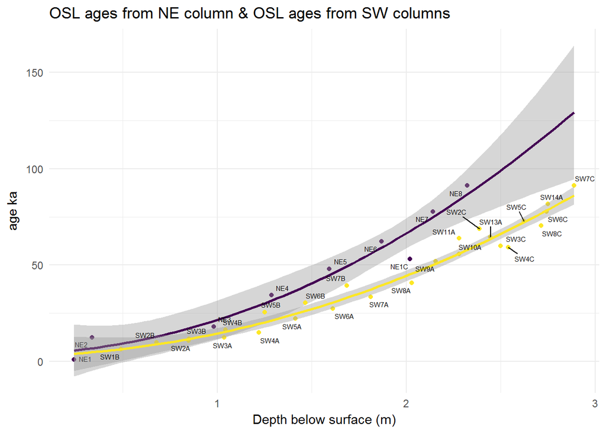